# Final R Reference

Ednita J Tavarez-Jimenez

# R Reference Guide

## Loading Data and Packages

```r
require(here)
library(palmerpenguins)
require(palmerpenguins)
here()
```

```
## [1] "/Users/ednitatavarez/Environmental Data/Environmental_Data"
```

```r
ginkgo <- read.csv(here("data", "ginkgo_data_2022.csv"))
dat_delo <- read.csv(here("data", "delomys.csv"))
dat_pen <- penguins
```

## Data Structure

```r
num_vec  = c(2, 4, 6)

## Create a vector of characters:
char_vec = c("a", "fantastic", "year")

num_vec
```

```
## [1] 2 4 6
```

```r
print(char_vec)
```

```
## [1] "a"         "fantastic" "year"
```

**Length**

```r
length(dat_delo)
```

```
## [1] 10
```

**Matrix**

```r
dim(dat_delo)
```

```
## [1] 1585   10
```

```r
dat_char <- matrix(nrow = length(num_vec), ncol = length(char_vec))

#data frame for dat_delo
dat_char = data.frame(char_vec, num_vec)
```

## Subsetting

```r
ginkgo$seeds_present
```

```
##   [1] FALSE FALSE FALSE FALSE FALSE FALSE FALSE FALSE FALSE FALSE FALSE FALSE
##  [13] FALSE FALSE FALSE FALSE FALSE FALSE FALSE FALSE FALSE FALSE FALSE FALSE
##  [25] FALSE FALSE FALSE FALSE FALSE FALSE FALSE FALSE FALSE FALSE FALSE FALSE
##  [37] FALSE FALSE FALSE FALSE  TRUE  TRUE  TRUE  TRUE  TRUE  TRUE  TRUE  TRUE
##  [49]  TRUE  TRUE FALSE FALSE FALSE FALSE FALSE FALSE FALSE FALSE FALSE  TRUE
##  [61]  TRUE  TRUE  TRUE  TRUE  TRUE  TRUE  TRUE  TRUE  TRUE FALSE FALSE FALSE
##  [73] FALSE FALSE FALSE FALSE FALSE FALSE FALSE FALSE FALSE FALSE FALSE FALSE
##  [85] FALSE FALSE FALSE FALSE FALSE FALSE FALSE FALSE FALSE FALSE FALSE FALSE
##  [97] FALSE FALSE FALSE FALSE FALSE FALSE FALSE FALSE FALSE FALSE FALSE FALSE
## [109] FALSE FALSE FALSE FALSE FALSE FALSE FALSE FALSE FALSE FALSE FALSE  TRUE
## [121]  TRUE  TRUE  TRUE  TRUE  TRUE  TRUE  TRUE  TRUE  TRUE FALSE FALSE FALSE
## [133] FALSE FALSE FALSE FALSE FALSE FALSE FALSE FALSE  TRUE  TRUE  TRUE  TRUE
## [145]  TRUE  TRUE  TRUE  TRUE  TRUE  TRUE FALSE FALSE FALSE FALSE FALSE FALSE
## [157] FALSE FALSE FALSE FALSE FALSE FALSE FALSE FALSE FALSE FALSE FALSE FALSE
## [169] FALSE FALSE FALSE FALSE FALSE FALSE FALSE FALSE FALSE FALSE FALSE FALSE
## [181] FALSE FALSE FALSE FALSE FALSE FALSE FALSE FALSE FALSE FALSE FALSE FALSE
## [193] FALSE FALSE FALSE FALSE FALSE FALSE FALSE FALSE FALSE FALSE FALSE FALSE
## [205] FALSE FALSE FALSE FALSE FALSE FALSE FALSE FALSE FALSE FALSE FALSE FALSE
## [217] FALSE FALSE FALSE FALSE
```

```r
ginkgo[1]
```

```
##     site_id
## 1       216
## 2       216
## 3       216
## 4       216
## 5       216
## 6       216
## 7       216
## 8       216
## 9       216
## 10      216
## 11     1896
## 12     1896
## 13     1896
## 14     1896
```

[output cut: 206 more lines]

```r
ginkgo [2,3]
```

```
## [1] 72
```

```r
ginkgo[,3]
```

```
##   [1]  85  72  64  76  85  75  72  81  87  87  94  92  70  84  61 102  82  64
##  [19]  53  66  69  55  56  64  60  59  57  53  68  56  75  63  82  83  60  67
##  [37]  75  92 110  54  77  59  51 100  92  77  99  62  80  86  63  79  91  72
##  [55]  64  53  71  61  70  93  75  87  86  87  95  88  85  95  95  52  84  74
##  [73]  87  76  57  92  94  79  97  50 100  97  63  96  97  70  83  80  85 100
##  [91] 112 115  83 106  95  80 120  76  50  90  94  69  93  59  60 103  95  90
## [109]  80  90 106  98  73  89  65  83 116  90  86 104  92 103 100  91 102  99
## [127]  98 104  80  68  62  77  86  72  70  63  72  65  69  67  35  67  63  71
## [145]  77  60  70  69  55  72  84 106  61 114  95  86  60  78  86  91  79  95
## [163]  72 102  72 107  95  91  94  90  98  63  58  67  92  75  74  73  73  94
## [181]  76  86  78  74  89  77  80  71  69  81  39  60  50  47  52  61  56  45
## [199]  64  42 103  84 118 120 100 111 104  94  78  70  92  48  79  91 111  44
## [217] 117  93 101 145
```

```r
Adelie <- subset(penguins, species =="Adelie")
```

## Numerical Data Exploration

```r
summary(Adelie)
```

```
##       species          island   bill_length_mm  bill_depth_mm
##  Adelie   :152   Biscoe   :44   Min.   :32.10   Min.   :15.50
##  Chinstrap:  0   Dream    :56   1st Qu.:36.75   1st Qu.:17.50
##  Gentoo   :  0   Torgersen:52   Median :38.80   Median :18.40
##                                 Mean   :38.79   Mean   :18.35
##                                 3rd Qu.:40.75   3rd Qu.:19.00
##                                 Max.   :46.00   Max.   :21.50
##                                 NA's   :1       NA's   :1
##  flipper_length_mm  body_mass_g       sex          year
##  Min.   :172       Min.   :2850   female:73   Min.   :2007
##  1st Qu.:186       1st Qu.:3350   male  :73   1st Qu.:2007
##  Median :190       Median :3700   NA's  : 6   Median :2008
##  Mean   :190       Mean   :3701               Mean   :2008
##  3rd Qu.:195       3rd Qu.:4000               3rd Qu.:2009
##  Max.   :210       Max.   :4775               Max.   :2009
##  NA's   :1         NA's   :1
```

```r
mean_ad <- mean(Adelie$bill_length_mm, trim = 0, na.rm = TRUE)
sd((!is.na(Adelie$bill_length_mm)))
```

```
## [1] 0.08111071
```

## Graphical Data Exploration

[figure not shown]

```r
plot(max_depth ~ max_width, data = ginkgo,
     col = "steelblue",
     pch = 11,
     cex = .5,
     main = "Ednita's plot of Ginkgo Max Width and Max Depth",
     xlab = "Max Leaf Depth",
     ylab = "Max Leaf Length",
     xlim = c(20,120),
     ylim = c(20,150))
```

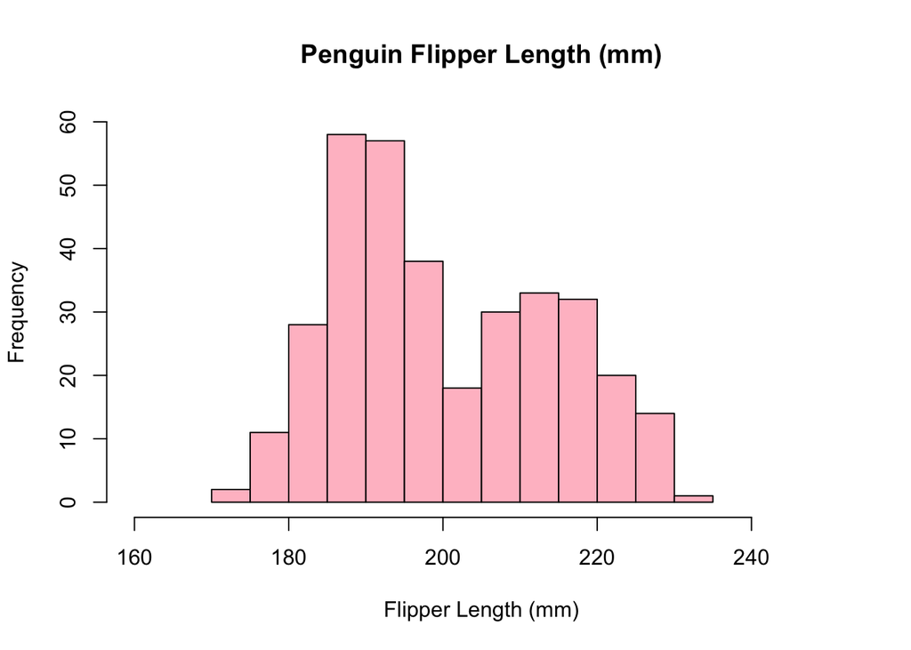

```r
hist(dat_pen$flipper_length_mm,
     col = "pink",
     main = "Penguin Flipper Length (mm)",
     xlab = "Flipper Length (mm)",
     xlim = c(160,250),
     ylim = c(0, 60),
     breaks = 20)
```

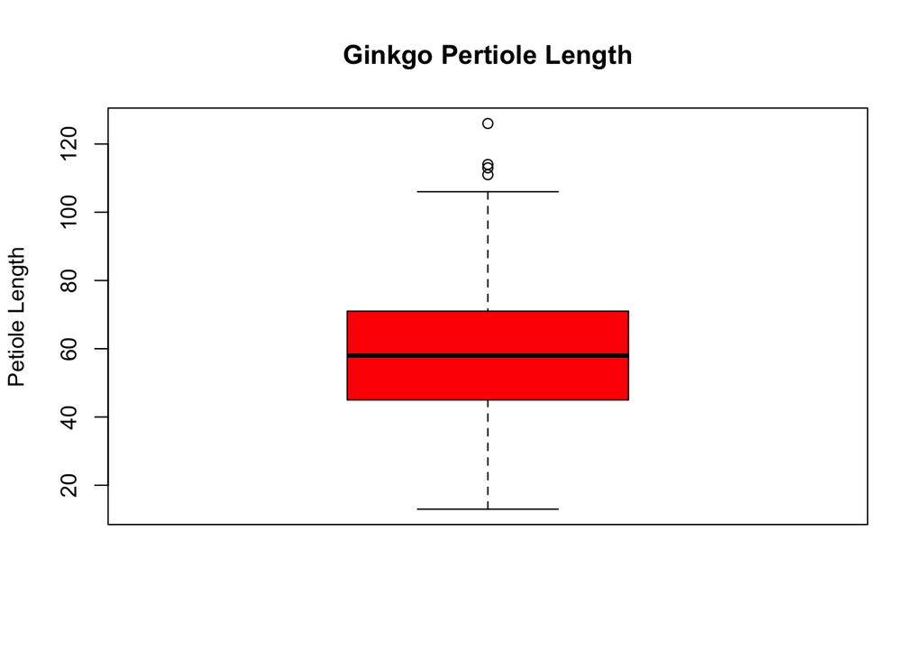

```r
boxplot(ginkgo$petiole_length,
        col = "red",
        main = "Ginkgo Pertiole Length",
        ylab = "Petiole Length")
```

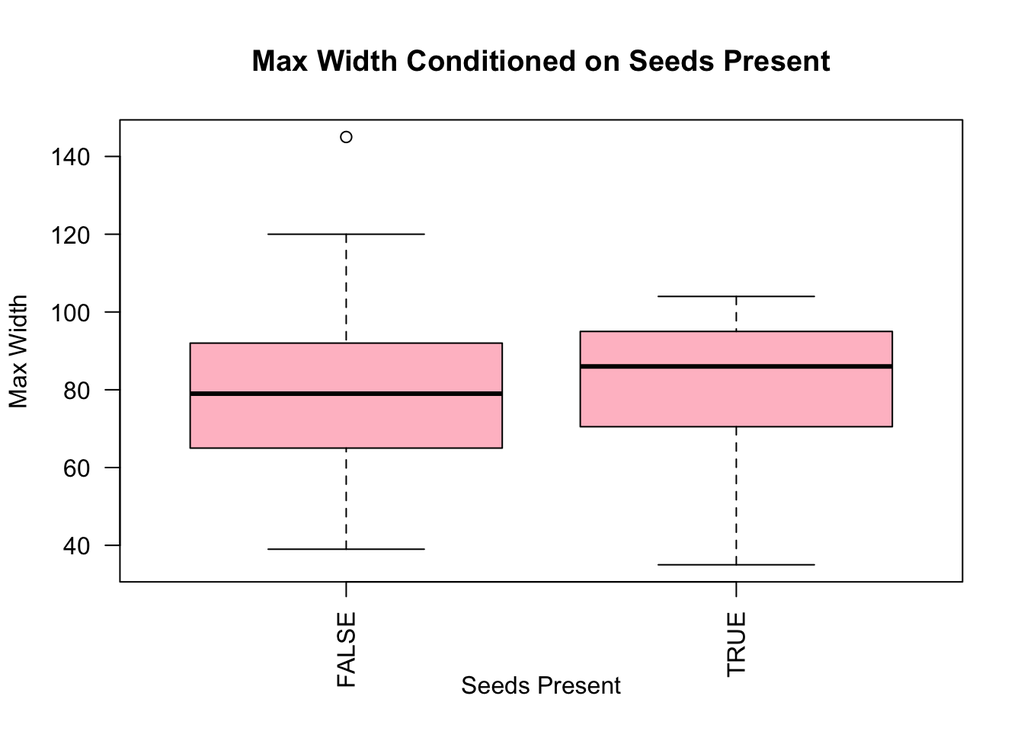

```r
boxplot(
  max_width ~ seeds_present,
  data = ginkgo,
  col = "Pink",
  las = 2,
  xlab = "Seeds Present",
  ylab = "Max Width",
  main = "Max Width Conditioned on Seeds Present")
```

[figure not shown]

```r
par(mfrow = c(2,2))

hist(dat_delo$body_mass,
     col = "steelblue",
     main = "Delomys Body Mass",
     xlab = "Delomys Body Mass")
hist(dat_pen$bill_length_mm,
     col = "pink",
     main = "Penguin's Bill Depth (mm)",
     xlab = "Penguin's Bill Length (mm)")
hist(Adelie$bill_depth_mm,
     col = "Red",
     main = "Adelie Bill Depth (mm)",
     xlab = "Bill Depth (mm)")
hist(dat_delo$body_length,
     col = "black",
     main = "Delomys Body Length",
     xlab = "Body Length")
```

## Distribution Functions

```r
dnorm(x = 4, mean = 0, sd = 1)
```

```
## [1] 0.0001338302
```

```r
pnorm(q = 4, mean = 0 , sd = 1)
```

```
## [1] 0.9999683
```

```r
qnorm(.75, mean = 0 , sd = 1)
```

```
## [1] 0.6744898
```

```r
dbinom(10, size = 11, prob = .5)
```

```
## [1] 0.005371094
```

```r
pbinom(50, size = 51, prob = .75)
```

```
## [1] 0.9999996
```

```r
qbinom(.111, size = 11, prob = .5)
```

```
## [1] 3
```

# Part 2: Data Analysis

# Data Exploration

**Q1: Qualitatively describe the relationship between body mass and length.**

The relationship between body mass and length look a bit linear with a small curve on the scatter plot.

[figure not shown]

```r
require(palmerpenguins)
plot(body_length ~ body_mass, data = dat_delo, main = "Delomys Body Mass and Body Length Histogram", xlab = "Body Mass", ylab = "Body Length", col = "black")
```

**Q2: Qualitatively describe the shapes of the histograms.**

The data does not appear to be normally distributed there is variation in the shape with body mass being a little skewed to the right. We care if the data is normally distributed or not because we would need to decide which model is appropriate to use or not going forward. In addition, we would want to see if there are any outliers if the data is not normally distributed.

[figure not shown]

```r
#Histogram of Penguin Body Mass and Body Length
par(mfrow = c(2, 1))
hist(dat_pen$body_mass_g, main = "Delomys Body Mass Histogram", xlab = "Body Mass", col = "pink")
hist(dat_delo$body_length, xlab = "Body Length",main = "Delomys Penguin Body Length Histogram", col = "steelblue")
```

**Q3 (2 pts.): Using both the histograms and normality tests, do you think the (unconditioned) body masses and body length are normally-distributed?**

Looking at the histogram and normality tests, I do not think the body masses and body length are normally distributed. In the histogram, we can see that the graphs are a bit skewed. In the shapiro test, the p-value is 2e-16 which is a lot less than the 0.05 so the null hypothesis would be rejected.

```r
dat_delo_1 = lm(body_mass ~ body_length, data = dat_delo)

summary(dat_delo_1)
```

```
##
## Call:
## lm(formula = body_mass ~ body_length, data = dat_delo)
##
## Residuals:
##     Min      1Q  Median      3Q     Max
## -85.091  -6.252  -0.886   5.696  57.577
##
## Coefficients:
##              Estimate Std. Error t value Pr(>|t|)
## (Intercept) -28.69307    1.65523  -17.34   <2e-16 ***
## body_length   0.63430    0.01427   44.46   <2e-16 ***
## ---
## Signif. codes:  0 '***' 0.001 '**' 0.01 '*' 0.05 '.' 0.1 ' ' 1
##
## Residual standard error: 9.936 on 1583 degrees of freedom
## Multiple R-squared:  0.5553, Adjusted R-squared:  0.5551
## F-statistic:  1977 on 1 and 1583 DF,  p-value: < 2.2e-16
```

```r
shapiro.test(residuals(dat_delo_1))
```

```
##
##  Shapiro-Wilk normality test
##
## data:  residuals(dat_delo_1)
## W = 0.91563, p-value < 2.2e-16
```

**Q4: Examine the three conditional boxplots.**

Looking at the conditional boxplot I don’t see a large variation in body mass between the two species and the sex. In the body mass conditioned by species boxplot we see that the dorsalis weights a little more than the sublineatus. However, in the body mass condition on sex boxplot we can see that the males weight a little more than the females.

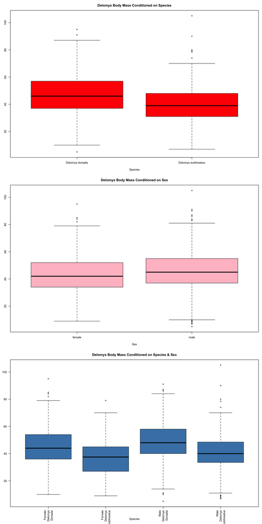

```r
# Conditional Box Plots

#1. Conditional boxplot of body mass, conditioned on species (column binomial)
par(mfrow = c(3, 1), mar = c(5,3,3,1))
boxplot(body_mass~binomial,data = dat_delo, main = "Delomys Body Mass Conditioned on Species", col = "red", xlab = "Species", ylab = "Body Mass")

boxplot(body_mass~sex,data = dat_delo, main = "Delomys Body Mass Conditioned on Sex", col = "pink", xlab = "Sex", ylab = "Body Mass")

boxplot(body_mass~binomial+sex,data = dat_delo, main = "Delomys Body Mass Conditioned on Species & Sex", col = "steelblue", xlab = "Species", ylab = "Body Mass", names = c("Female\n Delomys\n Dorsalis", "Female\n Delomys\n Sublineatus", "Male\n Delomys\n Dorsalis", "Male\n Delomys\n Sublineatus"), las = 2)
```

# Model Building

```r
#Building models for ANOVA
fit1 =
  lm(
    formula = body_length ~ body_mass,
    data = dat_delo)
coef(fit1)
```

```
## (Intercept)   body_mass
##  76.1246565   0.8754988
```

[figure not shown]

```r
slope_observed = coef(fit1)

plot(
  body_length ~ body_mass, data = dat_delo,
  main = "",
  xlab = "Body Length",
  ylab = "Body Mass")
abline(fit1)
```

```r
fit2  =
  lm(
    formula = body_mass ~ sex,
    data = dat_delo)
anova(fit2)
```

```
## Analysis of Variance Table
##
## Response: body_mass
##             Df Sum Sq Mean Sq F value    Pr(>F)
## sex          1   3062 3061.68  13.943 0.0001951 ***
## Residuals 1578 346507  219.59
## ---
## Signif. codes:  0 '***' 0.001 '**' 0.01 '*' 0.05 '.' 0.1 ' ' 1
```

```r
fit3 =
  lm(
    formula = body_mass ~ binomial,
    data = dat_delo)
anova(fit3)
```

```
## Analysis of Variance Table
##
## Response: body_mass
##             Df Sum Sq Mean Sq F value    Pr(>F)
## binomial     1  21290 21289.7  102.08 < 2.2e-16 ***
## Residuals 1583 330164   208.6
## ---
## Signif. codes:  0 '***' 0.001 '**' 0.01 '*' 0.05 '.' 0.1 ' ' 1
```

```r
fit4 =
  lm(
    formula = body_mass ~ sex + binomial,
    data = dat_delo)
anova(fit4)
```

```
## Analysis of Variance Table
##
## Response: body_mass
##             Df Sum Sq Mean Sq F value    Pr(>F)
## sex          1   3062  3061.7  14.958 0.0001144 ***
## binomial     1  23727 23727.1 115.923 < 2.2e-16 ***
## Residuals 1577 322780   204.7
## ---
## Signif. codes:  0 '***' 0.001 '**' 0.01 '*' 0.05 '.' 0.1 ' ' 1
```

```r
fit5 =
  lm(
    formula = body_mass ~ sex * binomial,
    data = dat_delo)
anova(fit5)
```

```
## Analysis of Variance Table
##
## Response: body_mass
##                Df Sum Sq Mean Sq  F value    Pr(>F)
## sex             1   3062  3061.7  14.9489  0.000115 ***
## binomial        1  23727 23727.1 115.8500 < 2.2e-16 ***
## sex:binomial    1      1     0.8   0.0039  0.950442
## Residuals    1576 322779   204.8
## ---
## Signif. codes:  0 '***' 0.001 '**' 0.01 '*' 0.05 '.' 0.1 ' ' 1
```

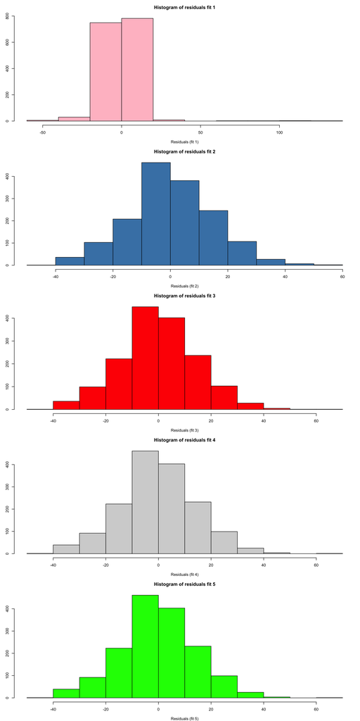

```r
#Histograms of model residuals
par(mfrow = c(5, 1), mar = c(4,3,3,1))
hist(residuals(fit1), main = "Histogram of residuals fit 1", xlab = "Residuals (fit 1)", col = "pink")
hist(residuals(fit2), main = "Histogram of residuals fit 2", xlab = "Residuals (fit 2)", col = "steelblue")
hist(residuals(fit3), main = "Histogram of residuals fit 3", xlab = "Residuals (fit 3)", col = "red")
hist(residuals(fit4), main = "Histogram of residuals fit 4", xlab = "Residuals (fit 4)")
hist(residuals(fit5), main = "Histogram of residuals fit 5", xlab = "Residuals (fit 5)", col = "green")
```

```r
#Shapiro Test fit 1
shapiro.test(residuals(fit1))
```

```
##
##  Shapiro-Wilk normality test
##
## data:  residuals(fit1)
## W = 0.73462, p-value < 2.2e-16
```

```r
#Shapiro Test fit 2
shapiro.test(residuals(fit2))
```

```
##
##  Shapiro-Wilk normality test
##
## data:  residuals(fit2)
## W = 0.99563, p-value = 0.0001541
```

```r
#Shapiro Test fit 3
shapiro.test(residuals(fit3))
```

```
##
##  Shapiro-Wilk normality test
##
## data:  residuals(fit3)
## W = 0.99535, p-value = 8.103e-05
```

```r
#Shapiro Test fit 4
shapiro.test(residuals(fit4))
```

```
##
##  Shapiro-Wilk normality test
##
## data:  residuals(fit4)
## W = 0.99525, p-value = 6.805e-05
```

```r
#Shapiro Test fit 5
shapiro.test(residuals(fit5))
```

```
##
##  Shapiro-Wilk normality test
##
## data:  residuals(fit5)
## W = 0.99526, p-value = 6.816e-05
```

# Model Interpretation

**Q7: What is the magnitude of the mass/length relationship?**

The magnitude of the mass/length relationship is that it is increasing by .87.

```r
knitr::kable(coef(summary(fit1)), digits = 2)
```

|  | Estimate | Std. Error | t value | Pr(>\|t\|) |
| --- | --- | --- | --- | --- |
| (Intercept) | 76.12 | 0.92 | 83.12 | 0 |
| body_mass | 0.88 | 0.02 | 44.46 | 0 |

```r
slope_observed = coef(fit1) [2]
summary(coef(fit1))
```

```
##    Min. 1st Qu.  Median    Mean 3rd Qu.    Max.
##  0.8755 19.6878 38.5001 38.5001 57.3124 76.1247
```

**Q8: What is the expected body length of an animal that weighs 100g?**

The expected body length of an animal that weights 100g is 164.12

```r
76.12 + .88*100
```

```
## [1] 164.12
```

**Q9: What is the expected body length of an animal that weighs 0g?**

The expected body length for an animal that weighs 0g is 76.12.

```r
76.12+.88*0
```

```
## [1] 76.12
```

**Q10: What is the base level for sex?**

The base level for sex are the females.

```r
knitr::kable(coef(summary(fit2)), digits = 2)
```

|  | Estimate | Std. Error | t value | Pr(>\|t\|) |
| --- | --- | --- | --- | --- |
| (Intercept) | 42.71 | 0.53 | 80.76 | 0 |
| sexmale | 2.78 | 0.75 | 3.73 | 0 |

```r
coef(fit2)
```

```
## (Intercept)     sexmale
##   42.711465    2.784133
```

```r
summary(fit2)
```

```
##
## Call:
## lm(formula = body_mass ~ sex, data = dat_delo)
##
## Residuals:
##     Min      1Q  Median      3Q     Max
## -40.496  -8.711  -0.496   9.504  59.504
##
## Coefficients:
##             Estimate Std. Error t value Pr(>|t|)
## (Intercept)  42.7115     0.5289  80.756  < 2e-16 ***
## sexmale       2.7841     0.7456   3.734 0.000195 ***
## ---
## Signif. codes:  0 '***' 0.001 '**' 0.01 '*' 0.05 '.' 0.1 ' ' 1
##
## Residual standard error: 14.82 on 1578 degrees of freedom
##   (5 observations deleted due to missingness)
## Multiple R-squared:  0.008758,   Adjusted R-squared:  0.00813
## F-statistic: 13.94 on 1 and 1578 DF,  p-value: 0.0001951
```

**Q11: What is the base level for binomial?**

Delomys dorsalis is the base level for binomial.

```r
knitr::kable(coef(summary(fit3)), digits = 2)
```

|  | Estimate | Std. Error | t value | Pr(>\|t\|) |
| --- | --- | --- | --- | --- |
| (Intercept) | 46.75 | 0.45 | 103.9 | 0 |
| binomialDelomys sublineatus | -7.68 | 0.76 | -10.1 | 0 |

```r
coef(fit3)
```

```
##                 (Intercept) binomialDelomys sublineatus
##                   46.752427                   -7.683058
```

```r
summary(fit3)
```

```
##
## Call:
## lm(formula = body_mass ~ binomial, data = dat_delo)
##
## Residuals:
##     Min      1Q  Median      3Q     Max
## -41.752  -9.069  -0.069   9.248  65.931
##
## Coefficients:
##                             Estimate Std. Error t value Pr(>|t|)
## (Intercept)                  46.7524     0.4500   103.9   <2e-16 ***
## binomialDelomys sublineatus  -7.6831     0.7605   -10.1   <2e-16 ***
## ---
## Signif. codes:  0 '***' 0.001 '**' 0.01 '*' 0.05 '.' 0.1 ' ' 1
##
## Residual standard error: 14.44 on 1583 degrees of freedom
## Multiple R-squared:  0.06058,    Adjusted R-squared:  0.05998
## F-statistic: 102.1 on 1 and 1583 DF,  p-value: < 2.2e-16
```

**Q12: Which sex is heavier? How do you know?**

The Male sex is heavier because they weight 45.4841 where as, the females only weight 42.7.

```r
female_sex <- 42.7 + 2.7841 * 0
male_sex <- 42.7 + 2.7841 * 1
```

**Q13: Which species is heavier? How do you know?**

Delomys dorsalis is heavier because they weight 46.7 where as, Delomys sublineatus only weights 39.01.

```r
coef(fit3)
```

```
##                 (Intercept) binomialDelomys sublineatus
##                   46.752427                   -7.683058
```

```r
summary(fit3)
```

```
##
## Call:
## lm(formula = body_mass ~ binomial, data = dat_delo)
##
## Residuals:
##     Min      1Q  Median      3Q     Max
## -41.752  -9.069  -0.069   9.248  65.931
##
## Coefficients:
##                             Estimate Std. Error t value Pr(>|t|)
## (Intercept)                  46.7524     0.4500   103.9   <2e-16 ***
## binomialDelomys sublineatus  -7.6831     0.7605   -10.1   <2e-16 ***
## ---
## Signif. codes:  0 '***' 0.001 '**' 0.01 '*' 0.05 '.' 0.1 ' ' 1
##
## Residual standard error: 14.44 on 1583 degrees of freedom
## Multiple R-squared:  0.06058,    Adjusted R-squared:  0.05998
## F-statistic: 102.1 on 1 and 1583 DF,  p-value: < 2.2e-16
```

```r
d_dor <- 46.7 - 7.6831 * 0
d_sub <- 46.7 - 7.6831 *1
```

## Anova Tables

**Q14: Are sex and species significant predictors for body mass?**

Yes because the p-value is under .05 for both the sex and the species in the additive and factorial ANOVA.

```r
anova(fit2)
```

```
## Analysis of Variance Table
##
## Response: body_mass
##             Df Sum Sq Mean Sq F value    Pr(>F)
## sex          1   3062 3061.68  13.943 0.0001951 ***
## Residuals 1578 346507  219.59
## ---
## Signif. codes:  0 '***' 0.001 '**' 0.01 '*' 0.05 '.' 0.1 ' ' 1
```

```r
anova(fit3)
```

```
## Analysis of Variance Table
##
## Response: body_mass
##             Df Sum Sq Mean Sq F value    Pr(>F)
## binomial     1  21290 21289.7  102.08 < 2.2e-16 ***
## Residuals 1583 330164   208.6
## ---
## Signif. codes:  0 '***' 0.001 '**' 0.01 '*' 0.05 '.' 0.1 ' ' 1
```

```r
anova(fit4)
```

```
## Analysis of Variance Table
##
## Response: body_mass
##             Df Sum Sq Mean Sq F value    Pr(>F)
## sex          1   3062  3061.7  14.958 0.0001144 ***
## binomial     1  23727 23727.1 115.923 < 2.2e-16 ***
## Residuals 1577 322780   204.7
## ---
## Signif. codes:  0 '***' 0.001 '**' 0.01 '*' 0.05 '.' 0.1 ' ' 1
```

```r
anova(fit5)
```

```
## Analysis of Variance Table
##
## Response: body_mass
##                Df Sum Sq Mean Sq  F value    Pr(>F)
## sex             1   3062  3061.7  14.9489  0.000115 ***
## binomial        1  23727 23727.1 115.8500 < 2.2e-16 ***
## sex:binomial    1      1     0.8   0.0039  0.950442
## Residuals    1576 322779   204.8
## ---
## Signif. codes:  0 '***' 0.001 '**' 0.01 '*' 0.05 '.' 0.1 ' ' 1
```

**Q15: Is there a significant interaction?**

There not a significant interaction because the p-value is .95 which is above the .05.

**Q16: Examine the p-values for the main effects (sex and species) in all four of the ANOVA tables. Does the significance level of either main effect change very much among the different models?**

Looking at the p-values for the main effects in all four of the ANOVA tables the significance level does not change very much among the different models.

##Model Comparison

**Q17: Which two models have the lowest AIC?**

```r
AIC(
  fit2,
  fit3,
  fit4,
  fit5)
```

```
##      df      AIC
## fit2  3 13006.80
## fit3  3 12966.36
## fit4  4 12896.73
## fit5  5 12898.72
```

**Q18: Which of the two models with lowest AIC scores would you select?**